# G-CSF PK-PD design evaluation

# Overview

This example evaluates a **G-CSF / filgrastim** population design with PFIM, based on the PK-PD model of Krzyzanski *et al.* (Krzyzanski et al. 2010).

The model describes subcutaneous filgrastim with quasi-steady-state target-mediated drug disposition (TMDD) and a myelopoiesis cascade for absolute neutrophil count (ANC). The population Fisher information matrix (FIM) is evaluated for **Design 1**: three parallel arms (1, 3 and 10 µg/kg), 10 subjects per arm, dense PK and ANC sampling on days 1 and 7.

## Objectives

1. **Evaluate** the population FIM of Design 1 (ODE model, two responses, `Combined2` residual error).
2. **Report** relative standard errors (RSE %) for fixed effects, IIV and residual error.
3. **Display** typical PK and ANC predictions (dense ODE re-simulation) together with SE / RSE bar charts.

The 11-state ODE FIM is expensive. During rendering, `example04_execute.R` reuses `vignettes/data/vignette4_evaluation_populationFIM.RDS` when present; otherwise it runs the evaluation. Set `PFIM_GCSF_FORCE_RUN=true` to ignore the cache. HTML `Report()` is rebuilt only when regenerating the FIM or when `PFIM_VIGNETTE_REPORT=true`.

# Experimental design

Design 1 is a three-arm parallel study. Body weight is fixed at 75 kg so the administered amount is $\mathrm{DOSE}\times\mathrm{WT}$. Seven daily subcutaneous doses are given at times $0, 24, \ldots, 144$ h. Bioavailability `FF` enters the depot initial condition (`ABS = FF * dose_ABS`).

| Arm | $n$ | Dose | Sampling |
| --- | --- | --- | --- |
| `dose_1ugkg` | 10 | 1 µg/kg × 75 kg | PK and ANC dense on days 1 and 7 |
| `dose_3ugkg` | 10 | 3 µg/kg × 75 kg | same grid |
| `dose_10ugkg` | 10 | 10 µg/kg × 75 kg | same grid |

# PK-PD model

Two observed responses:

- **RespPK** — serum G-CSF (ng/mL), algebraic quasi-steady-state free concentration from the central amount `CENT`.
- **RespPD** — circulating ANC ($10^3$/µL), ODE state `NB`.

The full right-hand sides are built by `.pfimGcsfModelEquations()` in `example04_execute.R`. The evaluation only needs the equation list, the algebraic PK output, and baseline initial conditions `.pfimGcsfBaselineICs()`.

```r
modelEquations = .pfimGcsfModelEquations()
outputs = list(RespPK = .pfimGcsfCp(), RespPD = "NB")
```

# Model parameters

Inter-individual variability ($\omega$) is set only for the parameters that are estimated (nonzero $\omega$). Fixed $\mu$ flags remove parameters from the FIM.

| Parameter | Description | $\mu$ | $\omega$ | Fixed μ |
| --- | --- | --- | --- | --- |
| *FF* | Bioavailability | 0.626 | 0 | Yes |
| *KA* | Absorption rate (h⁻¹) | 0.642 | 0 | No |
| *KEL* | Elimination rate of free G-CSF (h⁻¹) | 0.148 | √0.312 | No |
| *VD* | Central volume (L) | 2.56 | √0.328 | No |
| *KD* | Equilibrium dissociation constant (ng/mL) | 1.27 | 0 | No |
| *KINT* | Internalization rate (h⁻¹) | 0.101 | 0 | No |
| *KSI* | Binding capacity (Rmax-related) | 0.211 | √0.224 | No |
| *KMT* | Neutrophil elimination from blood (h⁻¹) | 0.0723 | 0 | No |
| *KTT* | Myeloid transit rate (h⁻¹) | 0.0102 | 0 | No |
| *NB0* | Baseline circulating ANC (10³/µL) | 1.65 | √0.298 | No |
| *SC1* | G-CSF EC₅₀ for stimulation (ng/mL) | 3.21 | √0.803 | No |
| *SM1* | Max. stimulation of production | 34.3 | √0.0128 | No |
| *SM2* | Max. stimulation of maturation | 32.3 | 0 | No |

`FR`, `D2`, `KOFF`, `KBB1`, `SM3` and `BAS` are fixed and do not appear in the FIM.

```r
modelParameters = list(
  ModelParameter(name = "KA",  distribution = LogNormal(mu = 0.642, omega = 0)),
  ModelParameter(name = "KEL", distribution = LogNormal(mu = 0.148, omega = sqrt(0.312))),
  ModelParameter(name = "VD",  distribution = LogNormal(mu = 2.56,  omega = sqrt(0.328))),
  # ... remaining parameters as in example04_execute.R
)
```

# Residual error model

PFIM `Combined2` stores residual **standard deviations** (`sigmaInter`, `sigmaSlope`). The variance form is

$$V = \sigma_{\mathrm{inter}}^2 + (\sigma_{\mathrm{slope}}\, f)^2.$$

| Response | Term | PFIM SD |
| --- | --- | --- |
| RespPK | proportional | √0.253 |
| RespPK | additive | 0, fixed |
| RespPD | proportional | √0.0227 |
| RespPD | additive | √2.10 |

```r
modelError = list(
  Combined2(output = "RespPK", sigmaInter = 0, sigmaSlope = sqrt(2.53e-01),
            sigmaInterFixed = TRUE),
  Combined2(output = "RespPD", sigmaInter = sqrt(2.10e+00),
            sigmaSlope = sqrt(2.27e-02))
)
```

# Administration, sampling times, arms

```r
WT = 75
dose_times = seq(0, 6 * 24, by = 24)

mk_arm = function(name, dose_ug_per_kg) {
  Arm(
    name = name, size = 10,
    administrations = list(Administration(
      outcome = "ABS", timeDose = dose_times,
      dose = rep(dose_ug_per_kg * WT, length(dose_times))
    )),
    samplingTimes = list(samplingPK, samplingPD),
    initialConditions = .pfimGcsfBaselineICs()
  )
}

design1 = Design(
  name = "gcsf_design1",
  arms = list(
    mk_arm("dose_1ugkg", 1),
    mk_arm("dose_3ugkg", 3),
    mk_arm("dose_10ugkg", 10)
  )
)
```

# Population FIM evaluation

```r
pfim_set_option(perf.fdLinearOnly = TRUE)

evaluationPop = Evaluation(
  name = "gcsf_design1",
  modelEquations = modelEquations,
  modelParameters = modelParameters,
  modelError = modelError,
  outputs = list(RespPK = .pfimGcsfCp(), RespPD = "NB"),
  designs = list(design1),
  fimType = "population",
  odeSolverParameters = list(atol = 1e-8, rtol = 1e-8)
)

evaluationPop = run(evaluationPop)
show(evaluationPop)
getRSE(evaluationPop)
```

```
  Population Fisher Matrix

                        μ_KA        μ_KEL          μ_VD          μ_KD        μ_KINT         μ_KSI         μ_KMT        μ_KTT         μ_NB0         μ_SC1         μ_SM1        μ_SM2       ω²_KEL
μ_KA            3971.1311156 1186.9218298 -2.036910e+01   -43.0557970   13963.30995   -244.505941 -6.798335e+02    7174.6916   -7.09980650   12.44065292  1.916216e+00    0.1939741  0.000000000
μ_KEL           1186.9218298 3276.6125964  6.240750e+00  -156.3236244    9250.01901     -4.066780  2.179500e+03    8740.5620   -2.35299025    0.73943343  4.034423e-01    1.2497026  0.000000000
μ_VD             -20.3691010    6.2407503  1.143137e+01     3.8378322     -94.80479     46.860295 -3.208658e+00    -728.5192    0.47053982    0.09993536  2.053618e-04   -0.1446296  0.000000000
μ_KD             -43.0557970 -156.3236244  3.837832e+00   284.9748591   -6639.55813   -193.952738 -1.759877e+03    6329.5127   -1.59457642   -2.93350653 -6.571671e-01    1.2214591  0.000000000
μ_KINT         13963.3099523 9250.0190055 -9.480479e+01 -6639.5581293  280625.07795   2536.417058  7.140062e+04 -162853.1163  -13.80764317  128.70795076  4.117431e+01  -40.5458885  0.000000000
μ_KSI           -244.5059408   -4.0667795  4.686030e+01  -193.9527380    2536.41706   1757.093492  1.291056e+03  -35042.1221    7.95346612    9.43280439  2.382649e+00   -9.9768049  0.000000000
μ_KMT           -679.8334795 2179.5003307 -3.208658e+00 -1759.8765917   71400.62066   1291.055650  2.516249e+05 -102117.7445  402.89285135  277.64187376  2.988309e+01  110.7877980  0.000000000
μ_KTT           7174.6915719 8740.5619687 -7.285192e+02  6329.5127120 -162853.11626 -35042.122084 -1.021177e+05 1371025.1260 -261.47968877 -581.86254459  4.025250e+02 -125.4816343  0.000000000
μ_NB0             -7.0998065   -2.3529903  4.705398e-01    -1.5945764     -13.80764      7.953466  4.028929e+02    -261.4797   35.37313289   -0.50505033 -8.216462e-02    1.0780692  0.000000000
μ_SC1             12.4406529    0.7394334  9.993536e-02    -2.9335065     128.70795      9.432804  2.776419e+02    -581.8625   -0.50505033    3.20793111 -6.164331e-02   -0.1954826  0.000000000
μ_SM1              1.9162163    0.4034423  2.053618e-04    -0.6571671      41.17431      2.382649  2.988309e+01     402.5250   -0.08216462   -0.06164331  1.947301e+00   -1.9885161  0.000000000
μ_SM2              0.1939741    1.2497026 -1.446296e-01     1.2214591     -40.54589     -9.976805  1.107878e+02    -125.4816    1.07806922   -0.19548259 -1.988516e+00    2.4205231  0.000000000
ω²_KEL             0.0000000    0.0000000  0.000000e+00     0.0000000       0.00000      0.000000  0.000000e+00       0.0000    0.00000000    0.00000000  0.000000e+00    0.0000000 96.431122784
ω²_VD              0.0000000    0.0000000  0.000000e+00     0.0000000       0.00000      0.000000  0.000000e+00       0.0000    0.00000000    0.00000000  0.000000e+00    0.0000000  0.121067757
ω²_KSI             0.0000000    0.0000000  0.000000e+00     0.0000000       0.00000      0.000000  0.000000e+00       0.0000    0.00000000    0.00000000  0.000000e+00    0.0000000  0.001812156
ω²_NB0             0.0000000    0.0000000  0.000000e+00     0.0000000       0.00000      0.000000  0.000000e+00       0.0000    0.00000000    0.00000000  0.000000e+00    0.0000000  0.007300912
ω²_SC1             0.0000000    0.0000000  0.000000e+00     0.0000000       0.00000      0.000000  0.000000e+00       0.0000    0.00000000    0.00000000  0.000000e+00    0.0000000  0.008543976
ω²_SM1             0.0000000    0.0000000  0.000000e+00     0.0000000       0.00000      0.000000  0.000000e+00       0.0000    0.00000000    0.00000000  0.000000e+00    0.0000000  0.779939847
σ_slope_RespPK     0.0000000    0.0000000  0.000000e+00     0.0000000       0.00000      0.000000  0.000000e+00       0.0000    0.00000000    0.00000000  0.000000e+00    0.0000000 17.867806893
σ_inter_RespPD     0.0000000    0.0000000  0.000000e+00     0.0000000       0.00000      0.000000  0.000000e+00       0.0000    0.00000000    0.00000000  0.000000e+00    0.0000000  0.868053723
σ_slope_RespPD     0.0000000    0.0000000  0.000000e+00     0.0000000       0.00000      0.000000  0.000000e+00       0.0000    0.00000000    0.00000000  0.000000e+00    0.0000000  8.192692601
                    ω²_VD       ω²_KSI       ω²_NB0       ω²_SC1       ω²_SM1 σ_slope_RespPK σ_inter_RespPD σ_slope_RespPD
μ_KA            0.0000000 0.000000e+00 0.000000e+00  0.000000000 0.000000e+00       0.000000      0.0000000       0.000000
```

[output cut: 83 more lines]

# Relative standard errors

RSE (%) reported by PFIM for Design 1.

## Fixed effects ($\mu$)

Fixed-effect RSE (%) for Design 1.

| Parameter | Description | RSE (%) |
| --- | --- | --- |
| $\mu_{\mathrm{KA}}$ | Absorption rate | 3.289 |
| $\mu_{\mathrm{KEL}}$ | Elimination rate of free G-CSF | 13.519 |
| $\mu_{\mathrm{VD}}$ | Central volume | 12.604 |
| $\mu_{\mathrm{KD}}$ | Equilibrium dissociation constant | 8.265 |
| $\mu_{\mathrm{KINT}}$ | Internalization rate | 3.822 |
| $\mu_{\mathrm{KSI}}$ | Binding capacity (Rmax-related) | 19.528 |
| $\mu_{\mathrm{KMT}}$ | Neutrophil elimination from blood | 4.066 |
| $\mu_{\mathrm{KTT}}$ | Myeloid transit rate | 17.017 |
| $\mu_{\mathrm{NB0}}$ | Baseline circulating ANC | 10.771 |
| $\mu_{\mathrm{SC1}}$ | G-CSF EC50 for stimulation | 20.851 |
| $\mu_{\mathrm{SM1}}$ | Max. stimulation of production | 8.290 |
| $\mu_{\mathrm{SM2}}$ | Max. stimulation of maturation | 7.665 |

## Inter-individual variances ($\omega^2$)

IIV variance ($\omega^2$) RSE (%) for Design 1.

| Parameter | Description | RSE (%) |
| --- | --- | --- |
| $\omega^2_{\mathrm{NB0}}$ | Baseline circulating ANC | 26.961 |
| $\omega^2_{\mathrm{KEL}}$ | Elimination rate of free G-CSF | 32.645 |
| $\omega^2_{\mathrm{VD}}$ | Central volume | 31.369 |
| $\omega^2_{\mathrm{KSI}}$ | Binding capacity (Rmax-related) | 41.941 |
| $\omega^2_{\mathrm{SC1}}$ | G-CSF EC50 for stimulation | 29.157 |
| $\omega^2_{\mathrm{SM1}}$ | Max. stimulation of production | 26.407 |

## Residual error ($\sigma$)

Console and report rows are labelled $\sigma_{\mathrm{slope/inter}}$ — the **Value** column is the SD, not the variance.

Residual-error SD and RSE (%) for Design 1.

| Parameter | Description | Value (SD) | RSE (%) |
| --- | --- | --- | --- |
| $\sigma_{\mathrm{slope,PK}}$ | PK proportional (SD) | 0.5030 | 1.950 |
| $\sigma_{\mathrm{slope,ANC}}$ | ANC proportional (SD) | 0.1507 | 3.271 |
| $\sigma_{\mathrm{inter,ANC}}$ | ANC additive (SD) | 1.4491 | 3.857 |

# Diagnostic plots

Overlay of the three dose groups (PK | ANC): **ODE re-simulation** on a dense $0..t_{\max}$ grid. Sampling times are shown as points. SE and RSE bar charts follow.

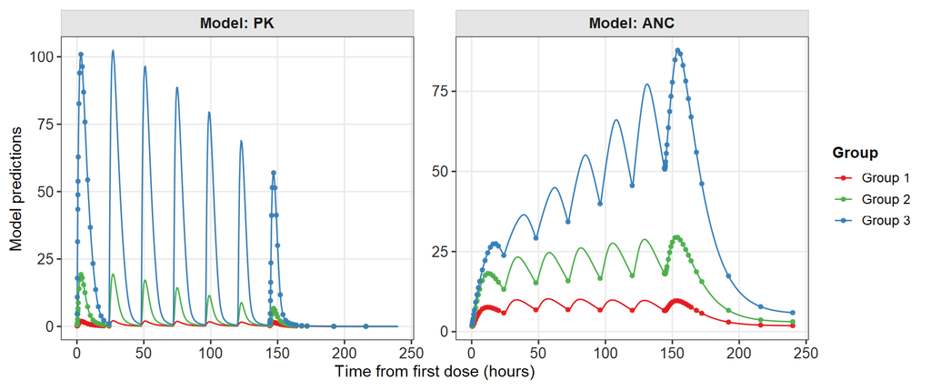

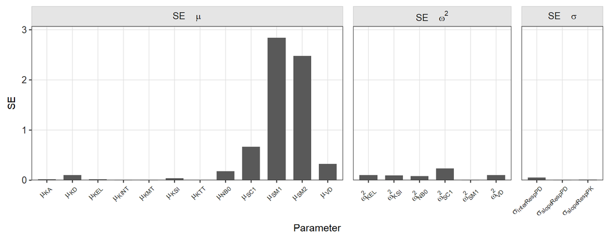

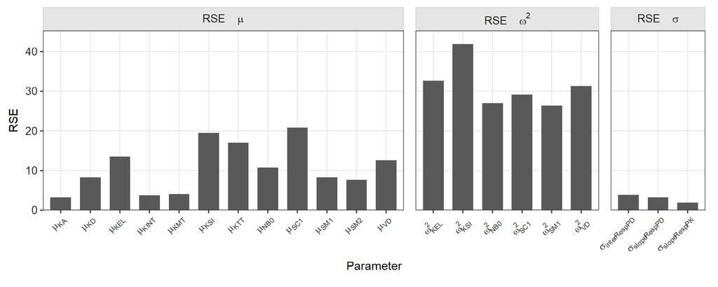

```r
plotOutcomesEvaluationModel
PFIM::plotSE(evaluationPop)
PFIM::plotRSE(evaluationPop)
```

# References

Krzyzanski, Wojciech, Paweł Wiczling, Peter J. Lowe, Etienne Pigeolet, Markus Fink, Amin Berghout, and Stephan Balser. 2010. “Population Modeling of Filgrastim PK-PD in Healthy Adults Following Intravenous and Subcutaneous Administrations.” *Journal of Clinical Pharmacology* 50 (9 Suppl): 101S–112S. https://doi.org/10.1177/0091270010376966.